# Results - Preproduction Well Count - Daily Annuli - Urban/Rural Stratification

# Gases

## Pollutant: Nitrogen Dioxide (NO2)

### Urban

**Descriptive statistics:**

- n monitor days = 594362
- n monitors in analytic data = 146

### Rural

**Descriptive statistics:**

- n monitor days = 123690
- n monitors in analytic data = 31

#### Adjusted linear regression model with monitor + month + basin:year FE

```
Call:
   felm(formula = no2_concentration_daily_max ~ wells_new_0to1km +      wells_new_1to2km + wells_new_2to3km + wells_new_3to4km +      wells_new_4to5km + wells_new_5to6km + wells_new_6to7km +      wells_new_7to8km + wells_new_8to9km + wells_new_9to10km +      wells_dw_new_0to1km + wells_dw_new_1to2km…

Residuals:
    Min      1Q  Median      3Q     Max
-30.354  -3.522  -0.464   2.658 153.084

Coefficients:
                       Estimate Std. Error t value Pr(>|t|)
wells_new_0to1km      1.4796173  1.0024300   1.476 0.139941
wells_new_1to2km      0.2514530  1.0855711   0.232 0.816825
wells_new_2to3km     -0.7258406  0.2680805  -2.708 0.006780 **
wells_new_3to4km      0.5950965  0.2617401   2.274 0.022993 *
wells_new_4to5km     -0.5528377  0.1606038  -3.442 0.000577 ***
wells_new_5to6km      0.4998505  0.2200833   2.271 0.023139 *
wells_new_6to7km      0.5819428  1.3325792   0.437 0.662328
wells_new_7to8km     -2.5384310  0.5901688  -4.301 1.70e-05 ***
wells_new_8to9km      0.3373459  0.4226220   0.798 0.424745
wells_new_9to10km    -1.0064743  0.3586650  -2.806 0.005015 **
wells_dw_new_0to1km   1.2679882  1.7621167   0.720 0.471785
wells_dw_new_1to2km  -0.8421488  1.6325172  -0.516 0.605955
wells_dw_new_2to3km  -1.3759983  0.1524073  -9.028  < 2e-16 ***
wells_dw_new_3to4km   0.0343314  0.1109249   0.310 0.756942
wells_dw_new_4to5km   0.4445082  0.2398046   1.854 0.063798 .
wells_dw_new_5to6km   1.5964882  0.3217181   4.962 6.98e-07 ***
wells_dw_new_6to7km   0.4407086  0.9602222   0.459 0.646261
wells_dw_new_7to8km   1.3234574  0.6314424   2.096 0.036093 *
wells_dw_new_8to9km  -0.4792708  0.5126073  -0.935 0.349809
wells_dw_new_9to10km  1.7093401  0.3640661   4.695 2.67e-06 ***
narr_precip          -0.1829353  0.0062708 -29.172  < 2e-16 ***
narr_temp             0.2753577  0.0073840  37.291  < 2e-16 ***
narr_wind_direction  -0.0027947  0.0003046  -9.175  < 2e-16 ***
---
Signif. codes:  0 ‘***’ 0.001 ‘**’ 0.01 ‘*’ 0.05 ‘.’ 0.1 ‘ ’ 1

Residual standard error: 6.316 on 57644 degrees of freedom
  (65943 observations deleted due to missingness)
Multiple R-squared(full model): 0.6311   Adjusted R-squared: 0.6304
Multiple R-squared(proj model): 0.04349   Adjusted R-squared: 0.04179
F-statistic(full model):966.7 on 102 and 57644 DF, p-value: < 2.2e-16
F-statistic(proj model): 113.9 on 23 and 57644 DF, p-value: < 2.2e-16
*** Standard errors may be too high due to more than 2 groups and exactDOF=FALSE
```

**Table**

| distance | distance_ordinal | direction | point_est | ci_lower | ci_upper |
| --- | --- | --- | --- | --- | --- |
| 0-1 | 1 | Upwind | 1.47961732 | -0.48515072 | 3.4443854 |
| 1-2 | 2 | Upwind | 0.25145297 | -1.87627193 | 2.3791779 |
| 2-3 | 3 | Upwind | -0.72584056 | -1.25127977 | -0.2004014 |
| 3-4 | 4 | Upwind | 0.59509646 | 0.08208451 | 1.1081084 |
| 4-5 | 5 | Upwind | -0.55283773 | -0.86762193 | -0.2380535 |
| 5-6 | 6 | Upwind | 0.49985045 | 0.06848598 | 0.9312149 |
| 6-7 | 7 | Upwind | 0.58194279 | -2.02991921 | 3.1938048 |
| 7-8 | 8 | Upwind | -2.53843100 | -3.69516481 | -1.3816972 |
| 8-9 | 9 | Upwind | 0.33734587 | -0.49099542 | 1.1656872 |
| 9-10 | 10 | Upwind | -1.00647431 | -1.70945945 | -0.3034892 |

[output cut: 10 more lines]

**Figure**

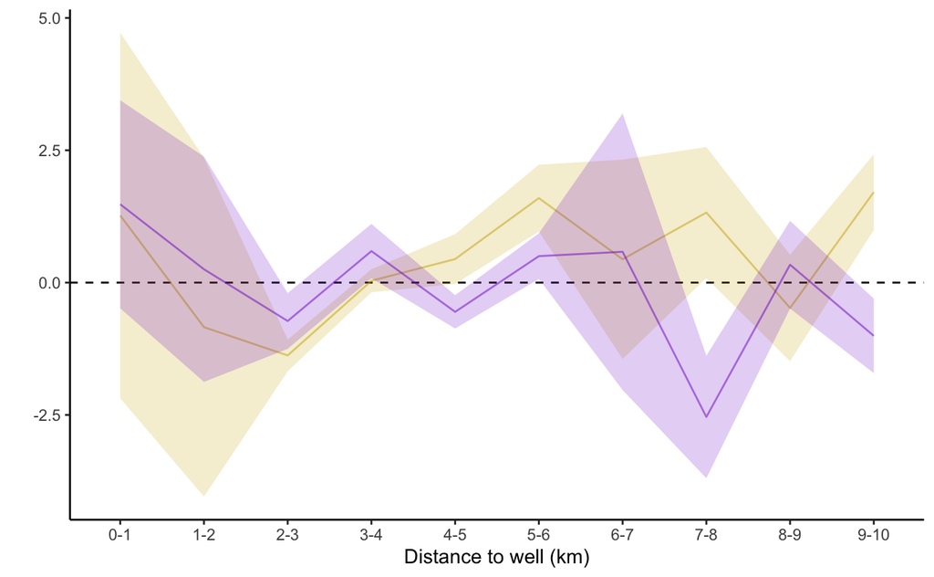

## Pollutant: Ozone (O3)

### Urban

**Descriptive statistics:**

- n monitor days = 897292
- n monitors in analytic data = 195

### Rural

**Descriptive statistics:**

- n monitor days = 364971
- n monitors in analytic data = 89

## Pollutant: Sulfur Dioxide (SO2)

### Urban

**Descriptive statistics:**

- n monitor days = 196011
- n monitors in analytic data = 54

### Rural

**Descriptive statistics:**

- n monitor days = 49105
- n monitors in analytic data = 11

#### Linear model with monitor + month + basin:year FE

# Particulate Matter

## Pollutant: Fine particulate matter (PM2.5)

### Urban

Descriptive statistics:

- n monitor days = 418135
- n monitors in analytic data = 159

### Rural

Descriptive statistics:

- n monitor days = 128589
- n monitors in analytic data = 58

#### Adjusted linear regression model with monitor + month + basin:year FE adjusted for temp + precip

```r
d <- data_in %>%
  filter(wells_new_4to5km > 0)
```

# VOCs

## Pollutant: Total NMOC

### Urban

Descriptive statistics:

- n monitor days = 94607
- n monitors in analytic data = 49

#### Linear model with monitor + month + basin:year FE

```
the matrix is either rank-deficient or indefinite
```

**Upwind**

*Table*

| distance | direction | point_est | ci_lower | ci_upper |
| --- | --- | --- | --- | --- |
| 0-1 | Upwind | NaN | NaN | NaN |
| 1-2 | Upwind | -35.6829455 | -74.252109 | 2.886218 |
| 2-3 | Upwind | 6.6346244 | -9.052791 | 22.322040 |
| 3-4 | Upwind | -8.8160504 | -20.553481 | 2.921380 |
| 4-5 | Upwind | -8.5619240 | -21.611835 | 4.487987 |
| 5-6 | Upwind | -2.9998856 | -9.980688 | 3.980917 |
| 6-7 | Upwind | 17.7756616 | 8.971276 | 26.580047 |
| 7-8 | Upwind | 2.7492682 | -5.835632 | 11.334168 |
| 8-9 | Upwind | 3.7006723 | -4.190748 | 11.592093 |
| 9-10 | Upwind | 0.9906914 | -3.302759 | 5.284142 |

**Figure**

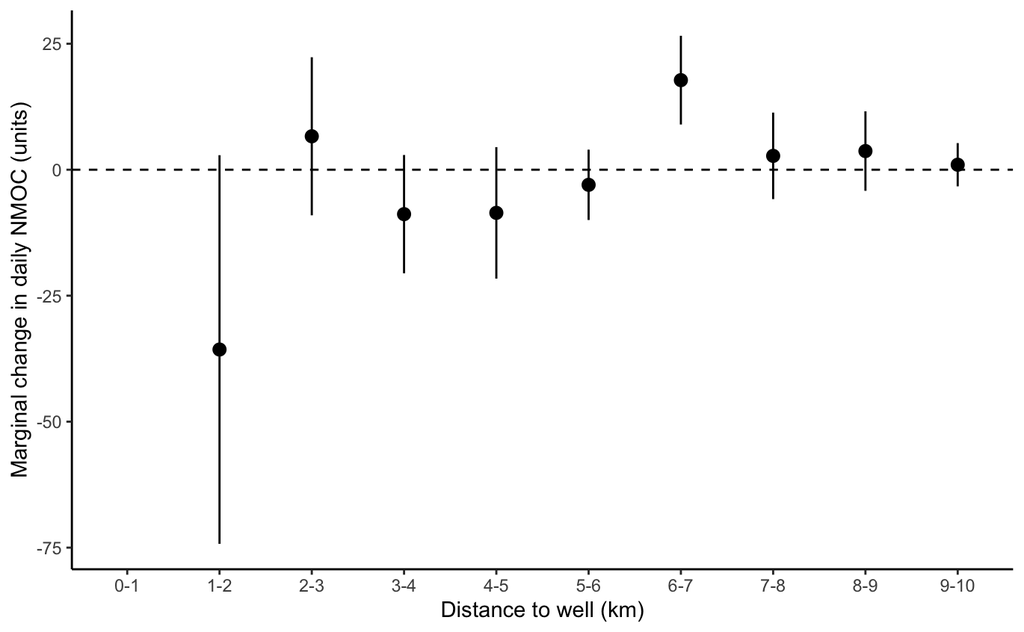

### Rural

#### Linear model with monitor + month + basin:year FE

```
Call:
   felm(formula = total_nmoc ~ wells_new_0to1km + wells_new_1to2km +      wells_new_2to3km + wells_new_3to4km + wells_new_4to5km +      wells_new_5to6km + wells_new_6to7km + wells_new_7to8km +      wells_new_8to9km + wells_new_9to10km + wells_dw_new_0to1km +      wells_dw_new_1to2km + wells_dw_new_2…

Residuals:
   Min     1Q Median     3Q    Max
-218.7  -17.1   -2.6    8.8 7821.9

Coefficients:
                      Estimate Std. Error t value Pr(>|t|)
wells_new_0to1km            NA         NA      NA       NA
wells_new_1to2km            NA         NA      NA       NA
wells_new_2to3km            NA         NA      NA       NA
wells_new_3to4km            NA         NA      NA       NA
wells_new_4to5km       -8.2680    89.5441  -0.092 0.926435
wells_new_5to6km        2.6405    21.8969   0.121 0.904022
wells_new_6to7km            NA         NA      NA       NA
wells_new_7to8km     -199.5245    38.8530  -5.135 2.89e-07 ***
wells_new_8to9km       -0.7778    30.7302  -0.025 0.979807
wells_new_9to10km      -2.9138    17.1169  -0.170 0.864833
wells_dw_new_0to1km         NA         NA      NA       NA
wells_dw_new_1to2km         NA         NA      NA       NA
wells_dw_new_2to3km         NA         NA      NA       NA
wells_dw_new_3to4km         NA         NA      NA       NA
wells_dw_new_4to5km    -9.5381   126.3484  -0.075 0.939827
wells_dw_new_5to6km         NA         NA      NA       NA
wells_dw_new_6to7km         NA         NA      NA       NA
wells_dw_new_7to8km  -177.5789   126.8021  -1.400 0.161422
wells_dw_new_8to9km   -11.1581    36.7052  -0.304 0.761143
wells_dw_new_9to10km    2.6101    21.6260   0.121 0.903939
narr_precip            -0.6628     0.4344  -1.526 0.127130
narr_temp               1.6445     0.4243   3.875 0.000107 ***
narr_wind_speed        -5.2191     1.7901  -2.915 0.003562 **
---
Signif. codes:  0 ‘***’ 0.001 ‘**’ 0.01 ‘*’ 0.05 ‘.’ 0.1 ‘ ’ 1

Residual standard error: 126 on 7613 degrees of freedom
  (12073 observations deleted due to missingness)
Multiple R-squared(full model): 0.07443   Adjusted R-squared: 0.06762
Multiple R-squared(proj model): 0.007447   Adjusted R-squared: 0.0001458
F-statistic(full model):10.93 on 56 and 7613 DF, p-value: < 2.2e-16
F-statistic(proj model): 2.483 on 23 and 7613 DF, p-value: 0.000103
*** Standard errors may be too high due to more than 2 groups and exactDOF=FALSE
```

**Upwind**

*Table*

| distance | direction | point_est | ci_lower | ci_upper |
| --- | --- | --- | --- | --- |
| 0-1 | Upwind | NaN | NaN | NaN |
| 1-2 | Upwind | NaN | NaN | NaN |
| 2-3 | Upwind | NaN | NaN | NaN |
| 3-4 | Upwind | NaN | NaN | NaN |
| 4-5 | Upwind | -8.268032 | -183.79922 | 167.26316 |
| 5-6 | Upwind | 2.640469 | -40.28345 | 45.56439 |
| 6-7 | Upwind | NaN | NaN | NaN |
| 7-8 | Upwind | -199.524519 | -275.68712 | -123.36191 |
| 8-9 | Upwind | -0.777850 | -61.01750 | 59.46180 |
| 9-10 | Upwind | -2.913831 | -36.46767 | 30.64001 |